# Analyze Incidents & Flights

CS3200 Final Project

SioWa Luo

Summer 2, 2025

## Analysis by Month

The following will be the table contain the total number of incident by type and month:

Total Number of Incidents by Type and Month

| Month | crew | faa | mechanical | medical | security | turbulence | weather | wildlife | TSA | Total |
| --- | --- | --- | --- | --- | --- | --- | --- | --- | --- | --- |
| January | 116 | 137 | 124 | 131 | 118 | 102 | 123 | 0 | 0 | 851 |
| February | 202 | 202 | 249 | 218 | 225 | 248 | 225 | 0 | 0 | 1569 |
| March | 210 | 244 | 223 | 219 | 234 | 221 | 227 | 0 | 0 | 1578 |
| April | 221 | 245 | 221 | 236 | 251 | 221 | 219 | 0 | 0 | 1614 |
| May | 239 | 229 | 218 | 229 | 259 | 244 | 271 | 1 | 0 | 1690 |
| June | 236 | 232 | 244 | 224 | 248 | 212 | 206 | 0 | 0 | 1602 |
| July | 217 | 253 | 251 | 251 | 232 | 244 | 243 | 0 | 0 | 1691 |
| August | 241 | 242 | 247 | 214 | 255 | 218 | 242 | 0 | 0 | 1659 |
| September | 244 | 215 | 241 | 249 | 235 | 261 | 226 | 0 | 0 | 1671 |
| October | 268 | 233 | 211 | 216 | 231 | 238 | 232 | 0 | 0 | 1629 |
| November | 230 | 242 | 234 | 252 | 245 | 245 | 221 | 0 | 1 | 1670 |
| December | 118 | 120 | 113 | 103 | 122 | 113 | 129 | 0 | 0 | 818 |

The monthly incident table shows a strong seasonal pattern in bird strike activity. Winter months seems to have a lower activity with December having the least incidents (818 incidents) and July show most acivity with 1691 incidents. In Summer month (May - September), the average 1663 incidents per month while the Winter month (December - February) average only 1079 incidents per month. This is around 54 % increased during the warmer months. The reason to this might due to the bird migration season which makes summer months a more critical periods for preventing bird strike incident.

## Analysis by Airline

Incident Summary and Average Delay by Airline

| Airline | Total Incidents | Average Delay (minutes) |
| --- | --- | --- |
| AM | 509 | 72.56 |
| AZ | 499 | 72.75 |
| EK | 491 | 72.52 |
| JL | 481 | 72.43 |
| G3 | 481 | 76.49 |
| TG | 478 | 72.34 |
| MH | 478 | 72.44 |
| DL | 474 | 72.85 |
| WN | 472 | 74.58 |
| LA | 467 | 74.59 |
| SQ | 463 | 69.51 |
| UA | 462 | 74.02 |
| KE | 458 | 72.25 |
| AC | 456 | 73.70 |
| LH | 455 | 73.60 |
| DY | 454 | 76.11 |
| AY | 453 | 73.00 |
| EY | 450 | 76.06 |
| IB | 450 | 74.78 |
| CX | 449 | 74.06 |
| CZ | 449 | 75.23 |
| AD | 444 | 71.41 |
| QR | 442 | 72.23 |
| U2 | 441 | 73.17 |
| AA | 440 | 72.38 |
| AV | 440 | 72.99 |
| FR | 440 | 75.84 |
| NH | 438 | 73.17 |
| SU | 435 | 74.17 |
| BA | 435 | 72.92 |
| NZ | 432 | 71.88 |
| TK | 430 | 75.40 |
| OZ | 429 | 72.04 |
| MU | 428 | 74.11 |
| AI | 428 | 75.98 |
| KL | 428 | 72.65 |
| SV | 427 | 75.88 |
| AF | 424 | 77.14 |
| QF | 423 | 70.64 |
| VN | 409 | 73.33 |

The airline analysis shows the performance between airline, with total incidents from 409 (VN) to 509 (AM) with a difference of 100 incidents. This show us that the incident is mostly correlates with operation volume. We observe a average delay vary by 7.6 minutes between the best (SQ at 69.51 minutes) and worst (AF at 77.14 minutes) airline. The small variance shows overall industry protocols for incident response. The differences are likely due to other operational reason than the safety protocol issue.

## Trend by Year

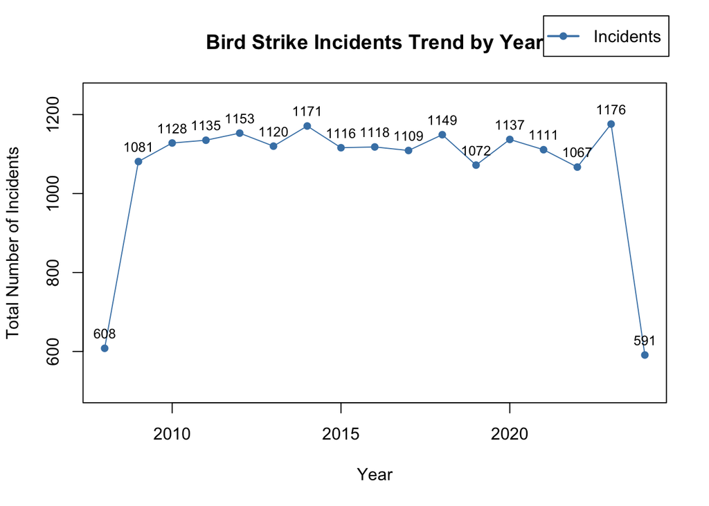

The visualization analayze 17 year from 2008 to 2024 showing the trend for airline safety evlotion. It start with 608 in 2008, but in the next year the incidents raise dramatically to 1081 incidents in 2009 and then maintain this level between 1067 - 1171 incidents annually through 2022 with average of 1119.1 incidents per year. In 2023 there is a peak occur with 1176 incidents. And at the very end of the trend, there is a sharp decline to 591 incidents in 2024 which create a situation that the beginning and ending years are having a significantly lower incidents acitivities compare to the middle of the trend.